# Final_R_reference

Hoa Ninh

17 Dec 2022

# Intro

This is a set of R examples for my personal reference beyond this course.

# R reference guide

## Loading Data and Packages

To install `here` I can just type:

```r
install.packages("here")
```

to load package

```r
require (here)
```

```
## here() starts at /Users/hoaninh/Documents/GitHub/Rreference
```

to read data

```r
here()
read.csv()
```

**Example**

This is how to load the `here` and `palmerpenguins` packages.

```r
install.packages("palmerpenguins")
```

```r
library(palmerpenguins)
```

**Example**

Ginkgo data: use the 2021 ginkgo data to create a `data.frame` called ginkgo using `here()` and `read.csv()`

```r
ginkgo = read.csv(here("data", "ginkgo_data_2021.csv"))
```

## Data Structures

`c()` is to create a vector

```r
# Numeric vector of random numbers
a = c(8, 3, 5, 6)

# Numeric vector of continuous numbers
b = c(1:4)

# Vector of string variables
color = c("red", "green", "blue", "yellow")
```

`length()` is to count the number of characters of the vector

```r
# count the number of characters of the vector a (I know it is 4)
length (b)
```

```
## [1] 4
```

```r
# count the number of characters of the vector color (I know it is 4)
length (color)
```

```
## [1] 4
```

`matrix()` is to create a matrix with number of columns and rows

```r
# Create a matrix containing 6 elements, with 3 columns and 3 rows
matrix(c(1:8), ncol = 3, nrow = 3 )
```

```
##      [,1] [,2] [,3]
## [1,]    1    4    7
## [2,]    2    5    8
## [3,]    3    6    1
```

```r
# Create a matrix containing 6 elements, with 3 columns and 3 rows, arranging by rows
matrix(c(1:8), ncol = 3, nrow = 3, byrow = TRUE)
```

```
##      [,1] [,2] [,3]
## [1,]    1    2    3
## [2,]    4    5    6
## [3,]    7    8    1
```

It requests 9 elements to fill in the (3 rows - 3 columns) matrix, so after 8, element 1 is added automatically to fill in the missing element.

`data.frame()`is to contain a range of vectors. In order to establish a data frame, all columns have to have the same number of observations.

```r
data.frame(color, a, b)
```

```
##    color a b
## 1    red 8 1
## 2  green 3 2
## 3   blue 5 3
## 4 yellow 6 4
```

**Example** Use the ginkgo data.frame to get information of:

- nrow()
- ncol()
- dim()

```r
# Count number of rows
nrow(ginkgo)
```

```
## [1] 756
```

```r
# Count number of columns
ncol(ginkgo)
```

```
## [1] 6
```

```r
# Count number of rows and columns
dim(ginkgo)
```

```
## [1] 756   6
```

## Subsetting

Sometime we just need one column from the available data, so we use subletting

**Example with ginkgo data**

```r
# $ Subset a data frame by name: select one of the columns in the ginkgo data
## Select max-width column
ginkgo$max_width

# [] Use subset by position to:
## select first row of the ginkgo data
ginkgo[1 , ]

## select the element in row 2, column 3
ginkgo[2, 3]

## select the 3rd column of the ginkgo data
ginkgo[, 3]

# subset() Use this function to retrieve all the data for Adelie penguins (in the species column) from the peuguins dataset.

Adelie = subset(penguins, species == "Adelie")
```

## Numerical Data Exploration

`summary`is used to give an overview about the data set, for example how many observations are included, the min, max, median and mean value.

**Example with ginkgo data**

```r
# Overview of ginkgo data
summary(ginkgo)
```

```
##     site_id      seeds_present     max_width        max_depth
##  Min.   : 1896   Mode :logical   Min.   : 16.00   Min.   : 19.00
##  1st Qu.: 3703   FALSE:636       1st Qu.: 63.00   1st Qu.: 43.00
##  Median : 6066   TRUE :120       Median : 74.00   Median : 51.00
##  Mean   : 6079                   Mean   : 74.34   Mean   : 58.51
##  3rd Qu.: 7206                   3rd Qu.: 85.00   3rd Qu.: 66.00
##  Max.   :12982                   Max.   :130.00   Max.   :145.00
##
##   notch_depth    petiole_length
##  Min.   : 0.00   Min.   :  8.00
##  1st Qu.: 0.00   1st Qu.: 34.00
##  Median : 0.00   Median : 47.00
##  Mean   : 2.99   Mean   : 48.25
##  3rd Qu.: 4.00   3rd Qu.: 60.00
##  Max.   :49.00   Max.   :113.00
##                  NA's   :4
```

```r
# Average of max_width
mean(ginkgo$max_width)
```

```
## [1] 74.33823
```

```r
# Standardized Deviation of max_width
sd(ginkgo$max_width)
```

```
## [1] 16.4203
```

**Example with Palmer penguin data**

`na.rm` is to omit NA value

```r
# Overview of Palmer penguin data
summary(penguins)
```

```
##       species          island    bill_length_mm  bill_depth_mm
##  Adelie   :152   Biscoe   :168   Min.   :32.10   Min.   :13.10
##  Chinstrap: 68   Dream    :124   1st Qu.:39.23   1st Qu.:15.60
##  Gentoo   :124   Torgersen: 52   Median :44.45   Median :17.30
##                                  Mean   :43.92   Mean   :17.15
##                                  3rd Qu.:48.50   3rd Qu.:18.70
##                                  Max.   :59.60   Max.   :21.50
##                                  NA's   :2       NA's   :2
##  flipper_length_mm  body_mass_g       sex           year
##  Min.   :172.0     Min.   :2700   female:165   Min.   :2007
##  1st Qu.:190.0     1st Qu.:3550   male  :168   1st Qu.:2007
##  Median :197.0     Median :4050   NA's  : 11   Median :2008
##  Mean   :200.9     Mean   :4202                Mean   :2008
##  3rd Qu.:213.0     3rd Qu.:4750                3rd Qu.:2009
##  Max.   :231.0     Max.   :6300                Max.   :2009
##  NA's   :2         NA's   :2
```

```r
# Average of bill_length_mm
mean(penguins$bill_length_mm, na.rm = TRUE)
```

```
## [1] 43.92193
```

```r
# Standardized Deviation of bill_length_mm
sd(penguins$bill_length_mm, na.rm = TRUE)
```

```
## [1] 5.459584
```

## Graphical Data Exploration

Plotting data is for data exploration.

**Scatterplot**

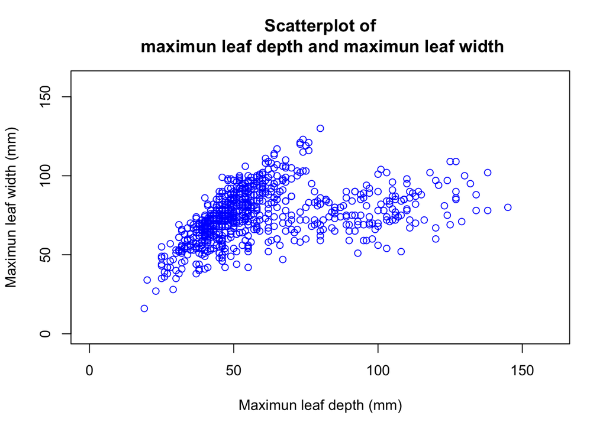

```r
# Using the ginkgo data, create a scatterplot of max leaf depth (x) and max leaf width (y)

plot(x = ginkgo$max_depth,
     y= ginkgo$max_width,
     col = "blue",
     pch = 21,
     cex = 1,
     main = "Scatterplot of\n maximun leaf depth and maximun leaf width",
     xlab = "Maximun leaf depth (mm)",
     ylab = "Maximun leaf width (mm)",
     xlim = c(0,160),
     ylim = c(0,160))
```

```r
# col = color of the point
# pch = plotting ‘character’, i.e., symbol to use
# cex = character (or symbol) expansion: a numerical vector
# main = title of the plot
# xlab = title of x axis
# ylab = title of y axis
# xlim ylim = numeric vectors of length 2, giving the x and y coordinates ranges
```

**Histogram**

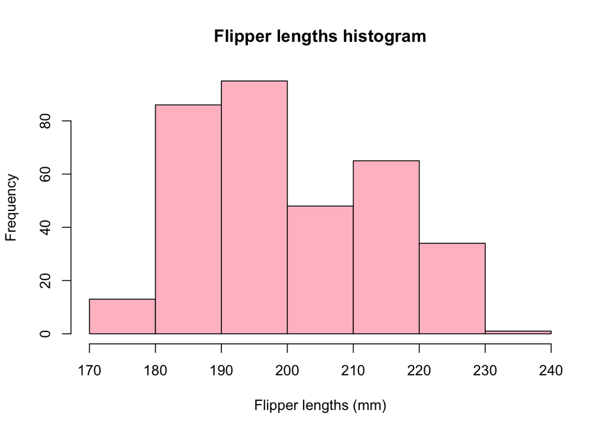

```r
# Create a histogram of penguin flipper lengths

hist(penguins$flipper_length_mm,
     breaks = 8,
     main = "Flipper lengths histogram",
     xlab = "Flipper lengths (mm)",
     col = "pink")
```

```r
# breaks = make references to the number of break points in the histogram
```

**Boxplot**

Simple boxplot

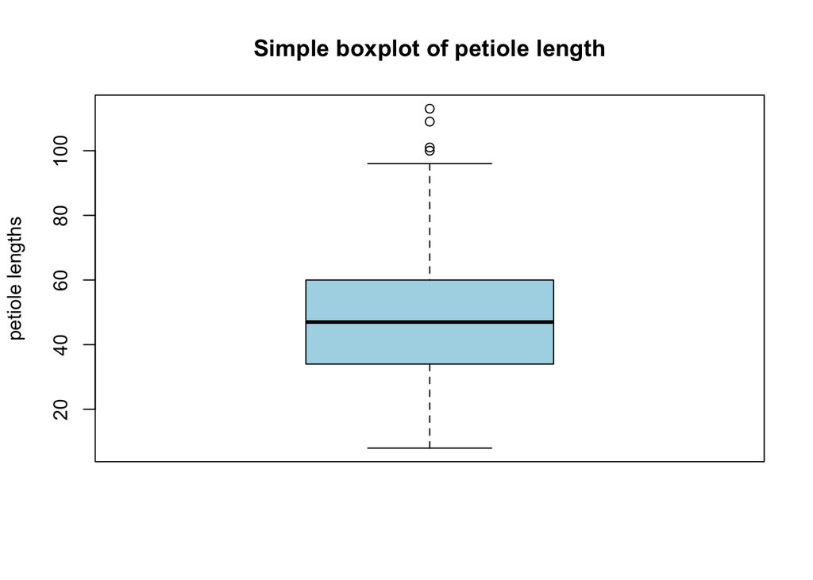

```r
# A simple boxplot of ginkgo petiole lengths
boxplot(ginkgo$petiole_length,
        main = "Simple boxplot of petiole length",
        ylab= "petiole lengths",
        col= "lightblue")
```

Conditional boxplot

`~` is used to add the condition between two variables

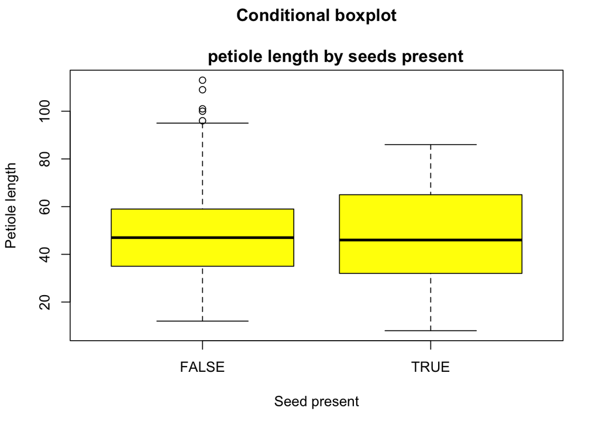

```r
# Conditional boxplot of one of the continuous variables conditioned on the seeds_present column

boxplot(petiole_length ~ seeds_present, data= ginkgo,
        main = "Conditional boxplot\n
        petiole length by seeds present",
        ylab = "Petiole length",
        xlab = "Seed present",
        col= "yellow")
```

** 4-panel figure of histograms**

`par` to make the grid so that I can illustrate a number of plots together.

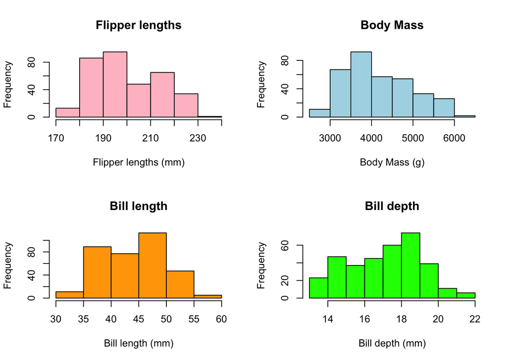

```r
# Create a 4-panel figure of histograms, arranged in a 2 by 2 grid.

## Create the 2 by 2 grid
par(mfrow= c(2,2))

## First histogram
hist(penguins$flipper_length_mm,
     breaks = 8,
     main = "Flipper lengths",
     xlab = "Flipper lengths (mm)",
     col = "pink")

## Second histogram
hist(penguins$body_mass_g,
     breaks = 8,
     main = "Body Mass",
     xlab = "Body Mass (g)",
     col = "lightblue")

## Third histogram
hist(penguins$bill_length_mm,
     breaks = 8,
     main = "Bill length",
     xlab = "Bill length (mm)",
     col = "orange")

## Forth histogram
hist(penguins$bill_depth_mm,
     breaks = 8,
     main = "Bill depth",
     xlab = "Bill depth (mm)",
     col = "green")
```

## Distribution Functions

**Normal Distribution**

`dnorm()`gives the density `pnorm()`gives the distribution function `qnorm()`gives the quantile function

```r
# Estimate the probability density with vector of quantiles = 8, vector of means = 4, vector of standard deviations = 2
dnorm(8, mean= 4, sd= 2)
```

```
## [1] 0.02699548
```

```r
# Estimate the cumulative distribution with vector of quantiles = 8, vector of means = 4, vector of standard deviations = 2
pnorm(8, mean= 4, sd= 2)
```

```
## [1] 0.9772499
```

```r
# estimate the quantile distribution with vector of probabilities = 0.25,  vector of means = 4, vector of standard deviations = 2
qnorm(0.25, mean = 4, sd= 2)
```

```
## [1] 2.65102
```

**Binomial Distribution**

`dbinom()`gives the density `pbinom()`gives the distribution function, `qbinom()`gives the quantile function

```r
# Estimate the probability density with vector of quantiles = 3, number of trials = 10, probability of success on each trial = 0.5
dbinom(3, size = 10, prob = 0.5)
```

```
## [1] 0.1171875
```

```r
# Estimate the cumulative distribution with vector of quantiles = 3, number of trials = 10, probability of success on each trial = 0.5
pbinom(5, size = 10, prob = 0.5)
```

```
## [1] 0.6230469
```

```r
# estimate the quantile distribution with vector of probabilities = 0.25,  number of trials = 10, probability of success on each trial = 0.5
qbinom(0.25, size = 10, prob = 0.5)
```

```
## [1] 4
```